# Using Land Registry Data to Estimate Market Value of Property by Area

Hamed Bastan-Hagh

# 1 Overview

This analysis uses the publicly available [price paid data](http://landregistry.data.gov.uk/app/ppd) from the Land Registry to determine whether it is possible to estimate a reasonable market value for each property type in each area. The conclusion is that the data are sufficient to set fairly broad, but useful, boundaries for transactions at ‘fair market value’ in most areas. A more useful approach may be to consider changes in property value, and to use comparisons of actual to expected price changes as a risk marker. Each of these approaches is summarised below.

Further work will be done to analyse the distribution of house prices, and whether this allows for useful application of the expected values and variance in any profiling applications.

NB. The next section deals with acquiring and preparing the data for analysis: the analysis with respect to average values and price changes are in sections 3 and 4.

# 2 Pre-Analysis

## 2.1 Data Loading and Preparation

To begin with we load the libraries required.

```r
library(tidyr)
library(dplyr)
library(data.table)
library(readr)
library(purrr)
library(lubridate)
library(stringr)
```

Now we create a function that will check whether the price paid data are present locally. If so it will read that into memory as `full_data`. If not it will download the price paid data and create the `full_data` object. The contents of this function show how the data will be structured (e.g. variable names and types).

```r
create_full_data_all_years <- function() {
    make_url <- function(year) {
        paste0("http://prod2.publicdata.landregistry.gov.uk.s3-website-eu-west-1.amazonaws.com/pp-",
               year,
               ".txt")
    }

    years <- seq(1995, 2017)

    urls <- map_chr(years, make_url)
    if(!dir.exists("data/")) {
        dir.create("data/")
    }
    setwd("data")
    walk(urls, function(x) {
        if(!file.exists(basename(x))) {
            download.file(x, basename(x), method = "curl")
        }
    })

    make_filename <- function(year) {
        paste("pp-",
              year,
              ".txt",
              sep = "")
    }

    filenames <- basename(urls)

    datalist <- map(filenames,
                    function(x) fread(x,
                                      sep = ",",
                                      header = F,
                                      col.names = c('tuid', 'price',
                                                    'date_of_transfer',
                                                    'postcde', 'prop_typ',
                                                    'old_new', 'duration',
                                                    'paon', 'saon', 'street',
                                                    'locality', 'town',
                                                    'district', 'county',
                                                    'ppd_type',
                                                    'rec_status')))

    full_data <- rbindlist(datalist)
    rm(datalist)
    setwd("..")

    full_data[
        ,
        prop_typ := as.factor(prop_typ)
        ][
            ,
            c("outcde", "incde") := tstrsplit(postcde, " ", fixed = TRUE)
            ][
                ,
                date_of_transfer := as_date(date_of_transfer)
                ][
                    ,
                    year := year(date_of_transfer)
                    ][
                        ,
                        tax_year := case_when(
                            month(date_of_transfer) > 4 ~ year + 1,
                            month(date_of_transfer) < 4 ~ year,
                            day(date_of_transfer) >= 6  ~ year + 1,
                            TRUE                        ~ year)
                        ]

    write_rds(full_data, './data/full_data_all_years.rds')
}
```

The next step is to run that function, checking first that the required object is not already in memory.

NB. These extra steps are to prevent unnecessary downloading of the data or creation of the data objects, as they are rather large.

```r
if(!exists('full_data')) {
    ifelse(file.exists('data/full_data_all_years.rds'),
           invisible(full_data <- read_rds('data/full_data_all_years.rds')),
           create_full_data())
}
```

## 2.2 Data Munging

Now apply grouping and summarising functions to the data to get what we need: entries for each combination of year, property type, and postcode area/outcode (e.g. M33, UB6).

```r
# Group the data by outcode, year, and property type, then summarise with a few
# key stats
if(!exists('by_outcde_yr_typ')) {
    ifelse(file.exists('data/by_outcde_yr_typ_all_yrs.rds'),
           by_outcde_yr_typ <- read_rds('data/by_outcde_yr_typ_all_yrs.rds'),
           by_outcde_yr_typ <- full_data[,
                                         .(.N,
                                           avg_price = mean(price),
                                           median = quantile(price, .50),
                                           sd = sd(price),
                                           q05 = quantile(price, .05),
                                           q10 = quantile(price, .10),
                                           q15 = quantile(price, .15),
                                           q20 = quantile(price, .20),
                                           q25 = quantile(price, .25),
                                           q30 = quantile(price, .30),
                                           q35 = quantile(price, .35),
                                           q40 = quantile(price, .40),
                                           q45 = quantile(price, .45),
                                           q55 = quantile(price, .55),
                                           q60 = quantile(price, .60),
                                           q65 = quantile(price, .65),
                                           q70 = quantile(price, .70),
                                           q75 = quantile(price, .75),
                                           q80 = quantile(price, .80),
                                           q85 = quantile(price, .85),
                                           q90 = quantile(price, .90),
                                           q95 = quantile(price, .95)),
                                         keyby = .(outcde, prop_typ, tax_year)])
}
```

Save the summarised table to file to speed up the process when re-running.

```r
# Write out the data.table to rds
if(!file.exists('data/by_outcde_yr_typ_all_yrs.rds')) {
    write_rds(by_outcde_yr_typ, 'data/by_outcde_yr_typ_all_yrs.rds')
}
```

# 3 Property Price By Type and Location

Our first aim is to determine whether we have sufficient data to give a meaningful expected value for a given property transaction. There are at least three elements to consider with this:

- What categorical variables are available to us for segmenting the data?
- Do we have sufficient observations in each of those segments for reliable inference?
- Does the dispersion of the data points in each segment allow us to set reasonable error bounds for the expected value?

Each will be addressed in turn.

## 3.1 Categorical Variables

Let’s consider the variables in the full price paid data.

```r
str(full_data)
```

```
Classes ‘data.table’ and 'data.frame':  22671565 obs. of  20 variables:
 $ tuid            : chr  "{5BBE9CB3-6332-4EB0-9CD3-8737CEA4A65A}" "{20E2441A-0F16-49AB-97D4-8737E62A5D93}" "{D893EE64-4464-44B5-B01B-8E62403ED83C}" "{F9F753A8-E56A-4ECC-9927-8E626A471A92}" ...
 $ price           : int  42000 95000 74950 43500 63000 29995 105000 121250 43000 128500 ...
 $ date_of_transfer: Date, format: "1995-12-21" "1995-03-03" "1995-10-03" "1995-11-14" ...
 $ postcde         : chr  "NE4 9DN" "RM16 4UR" "CW10 9ES" "TS23 3LA" ...
 $ prop_typ        : Factor w/ 5 levels "D","F","O","S",..: 4 4 1 4 4 4 1 2 5 5 ...
 $ old_new         : chr  "N" "N" "Y" "N" ...
 $ duration        : chr  "F" "F" "F" "F" ...
 $ paon            : chr  "8" "30" "15" "19" ...
 $ saon            : chr  "" "" "" "" ...
 $ street          : chr  "MATFEN PLACE" "HEATH ROAD" "SHROPSHIRE CLOSE" "SLEDMERE CLOSE" ...
 $ locality        : chr  "FENHAM" "GRAYS" "MIDDLEWICH" "BILLINGHAM" ...
 $ town            : chr  "NEWCASTLE UPON TYNE" "GRAYS" "MIDDLEWICH" "BILLINGHAM" ...
 $ district        : chr  "NEWCASTLE UPON TYNE" "THURROCK" "CONGLETON" "STOCKTON-ON-TEES" ...
 $ county          : chr  "TYNE AND WEAR" "THURROCK" "CHESHIRE" "STOCKTON-ON-TEES" ...
 $ ppd_type        : chr  "A" "A" "A" "A" ...
 $ rec_status      : chr  "A" "A" "A" "A" ...
 $ outcde          : chr  "NE4" "RM16" "CW10" "TS23" ...
 $ incde           : chr  "9DN" "4UR" "9ES" "3LA" ...
 $ year            : num  1995 1995 1995 1995 1995 ...
 $ tax_year        : num  1996 1995 1996 1996 1996 ...
 - attr(*, ".internal.selfref")=<externalptr>
```

For this analysis we will use three variables to segment the data:

- **postcode area** (or outcode);
- **property type**: Detached, Flat, Semi-Detached, Terraced, Other;
- **tax_year**.

It might be possible to do a more detailed analysis of location using geo data, based on the full postcode, but for the purposes of this work we will cluster properties based on their postcode area and consider it as a discrete variable.

## 3.2 Data Completeness

We have our three categories for the analysis, so we start by checking what proportion of the tax year-property type-outcode groups have a reasonable number of observations, say 10.

```r
# Check how many groups have at least 10 data points
paste0(round((100 * nrow(by_outcde_yr_typ[N > 10]) / nrow(by_outcde_yr_typ))),
       "% of outcode, year, property type groups have at least 10 data points.")
```

```
[1] "83% of outcode, year, property type groups have at least 10 data points."
```

However we cannot be sure we have every possible combination of tax year-property type-outcode is present in our data. So we compare our list to the reference list of postcode areas from the Ordnance Survey, to ensure that we have entries for every possible combination.

In this analysis the postcode lists have already been downloaded from the Ordnance Survey in `.csv` format, and stored in a directory called `OS_data`.

```r
# Combine the Ordnance Survey postcode list csv files to get full list of all
# UK outcodes.
fils <- list.files('./data/OS_data',
                   pattern = '.csv$',
                   full.names = TRUE)
pcdes <- rbindlist(lapply(fils,
                          fread))[,
                                  .(pcde = paste(str_extract(V1,
                                                             '^[A-z]{1,2}\\d{1,2}[A-z]?'),
                                                 str_extract(V1,
                                                             '\\d[A-z]{2}$')),
                                    outcde = str_extract(V1,
                                                         '^[A-z]{1,2}\\d{1,2}[A-z]?'),
                                    incde = str_extract(V1,
                                                        '\\d[A-z]{2}$'))]
# We only need the outcodes, so we can reduce the size of the object
# dramatically.
# Importantly we add a row for a blank string, to match to those sales in the
# price paid data with no geographical location.
#
# Then we cross join that table with all possible years and property types.
# Drop cols and duplicates from pcdes to save memory
outcdes <- rbindlist(list(list(''),
                          unique(pcdes[, .(outcde)])))
# Prepare all_outcdes for binding with year and type data
outcdes_yrs_typs <- CJ(outcde = outcdes$outcde,
                       tax_year = 1995:2018,
                       prop_typ = c('D', 'F', 'O', 'S', 'T'))
```

We now join the outcodes to the price paid data, and add a logical column to flag Scottish postcodes. Due to the separation of Scottish property taxes we will remove those areas from the analysis.

The two `sapply()` operations at the end of this section test for missing values in the combined dataset.

```r
# Left Join full list of outcodes with the price paid data, see which have no
# data. Add logical for Scottish pcdes.
scot_area_cdes <- c('AB', 'DD', 'DG', 'EH', 'FK', 'G', 'HS', 'IV',
                    'KA', 'KW', 'KY', 'ML', 'PA', 'PH', 'TD', 'ZE')
scot_outcde_regx <- paste0('^',
                           scot_area_cdes,
                           '[0-9]{1,2}',
                           collapse = '|')
setkey(outcdes_yrs_typs, outcde, prop_typ, tax_year)
setkey(by_outcde_yr_typ, outcde, prop_typ, tax_year)
all_ppdata <- by_outcde_yr_typ[outcdes_yrs_typs][
    ,
    scottish := (grepl(scot_outcde_regx, outcde))
]
sapply(all_ppdata, function(x) {max(is.na(x))})
```

```
   outcde  prop_typ  tax_year         N avg_price    median        sd       q05       q10       q15       q20
        0         0         0         1         1         1         1         1         1         1         1
      q25       q30       q35       q40       q45       q55       q60       q65       q70       q75       q80
        1         1         1         1         1         1         1         1         1         1         1
      q85       q90       q95  scottish
        1         1         1         0
```

```r
sapply(all_ppdata, function(x) {sum(is.na(x))})
```

```
   outcde  prop_typ  tax_year         N avg_price    median        sd       q05       q10       q15       q20
        0         0         0    123807    123807    123807    129801    123807    123807    123807    123807
      q25       q30       q35       q40       q45       q55       q60       q65       q70       q75       q80
   123807    123807    123807    123807    123807    123807    123807    123807    123807    123807    123807
      q85       q90       q95  scottish
   123807    123807    123807         0
```

Now we separate the Scottish data, leaving an object `main_ppdata` that we can use for analysis. We also impute zeroes for the `NA` entries in the `N` field, which will make our analysis easier.

```r
# Separate Scottish data
main_ppdata <- all_ppdata[scottish == FALSE]
main_ppdata$N[is.na(main_ppdata$N)] <- 0L
scot_ppdata <- all_ppdata[scottish == TRUE]
```

For which outcode-year-type groups do we have sufficient data for reliable inferences?

We can visualise this to begin with.

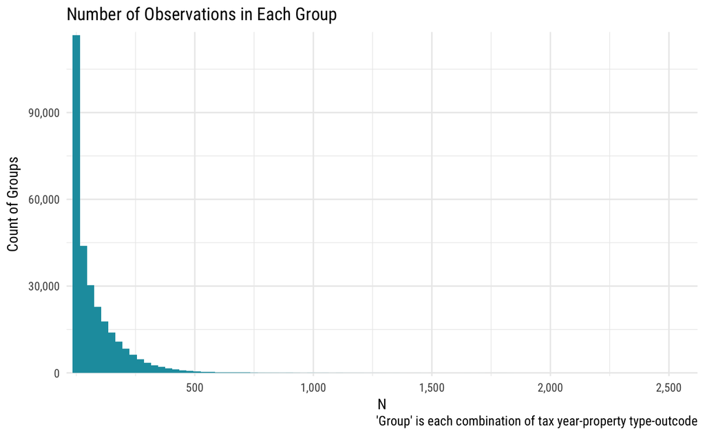

This doesn’t look promising, but there is a long tail here that may not be captured clearly in the histogram.

```r
main_ppdata[,
            .N,
            keyby = .(low_data = (N < 10 & !is.na(N)),
                      no_data = (N == 0))
            ]
```

| low_data | no_data | N |
| --- | --- | --- |
| FALSE | FALSE | 188161 |
| TRUE | FALSE | 33544 |
| TRUE | TRUE | 69415 |

However this does not take account of the clustering of property transactions. What proportion of property transactions occur in groups with 10 or more observations?

```r
main_ppdata[,
            .(total_transactions = sum(N)),
            by = .(N >= 10)]
```

| N >= 10 | total_transactions |
| --- | --- |
| FALSE | 146460 |
| TRUE | 22489833 |

This is more promising: only 1% of property transactions in the tax years 1995-2017 took place in groups with fewer than 10 data points. We can test this with a higher threshold for ‘good data’ of n = 20.

```r
main_ppdata[,
            .(total_transactions = sum(N)),
            by = .(N >= 20)]
```

| N >= 20 | total_transactions |
| --- | --- |
| FALSE | 448848 |
| TRUE | 22187445 |

2% of transactions are in groups that fall below this increased threshold. We can also check whether this remains consistent year-on-year.

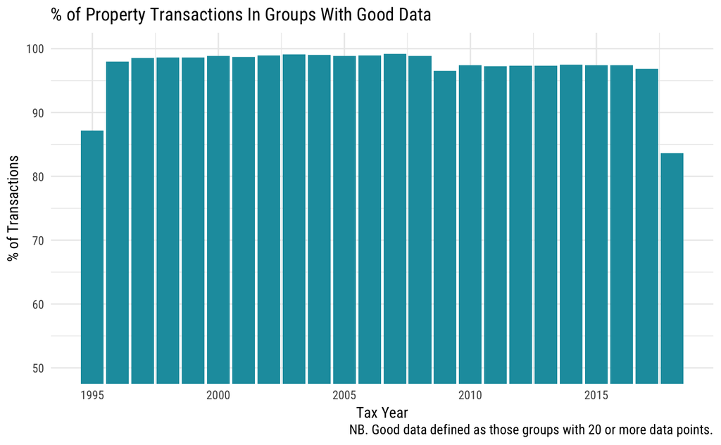

```r
data_totals <- main_ppdata[,
                           .(total_transactions = sum(N)),
                            by = tax_year]
good_data_totals <- main_ppdata[,
                                good_data := (N >= 20)][
                                    ,
                                    .(transactions = sum(N)),
                                    by = .(tax_year, good_data)
                                    ][
                                        good_data == TRUE
                                        ]
setkey(good_data_totals, tax_year)
setkey(data_totals, tax_year)
data_totals[good_data_totals][,
                              .(good_data_pct = 100 * (transactions / total_transactions)),
                              by = tax_year] %>%
    ggplot(., aes(tax_year, good_data_pct)) +
    geom_bar(stat = 'identity', fill = "#1b9cad") +
    coord_cartesian(ylim = c(50, 100)) +
    ggtitle("% of Property Transactions In Groups With Good Data") +
    labs(x = "Tax Year", y = "% of Transactions",
         caption = "NB. Good data defined as those groups with 20 or more data points.") +
    theme_minimal(base_family = "Roboto Condensed")
```

NB. The two years with much lower totals are those for which we have incomplete data, because the Land Registry source data is based on calendar years. This further strengthens our confidence in the data quality.

## 3.3 Dispersion of Price Paid Data

Given that we have reasonable quality of data, we can now consider whether the data points themselves are useful. The starting point for this is to consider a specific example: what are the prices for terraced houses in West Kensington (W14) in the 2017 tax year?

```r
by_outcde_yr_typ[prop_typ == "T" & tax_year == 2017 & outcde == "W14",
                 .(avg_price, median, sd, q25, q75)]
```

| avg_price | median | sd | q25 | q75 |
| --- | --- | --- | --- | --- |
| 2727334 | 2230000 | 3607777 | 1300000 | 2775000 |

### 3.3.1 Trends over time

We need to consider whether the within-year trends seem to be consistent between years. Remember that we are considering three levels in our grouping:

- tax year;
- property type;
- area (i.e. postal outcode).

We can examine each of these individually, and then combine them and consider overall effects.

#### 3.3.1.1 Year On Year Trends

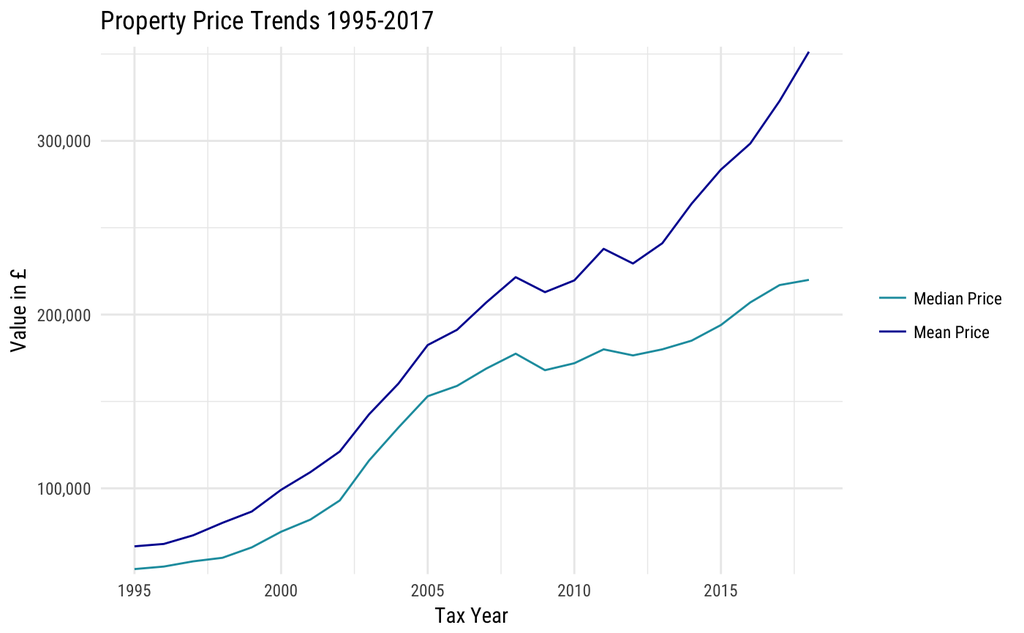

```r
melt(full_data[,
          .("Median Price" = quantile(price, .5),
            "Mean Price" = round(mean(price, na.rm = TRUE))),
          by = tax_year],
     id.vars = "tax_year",
     measure_vars = c("med_price", "avg_price")) %>%
    ggplot(., aes(x = tax_year, y = value, colour = variable)) +
    geom_line() +
    theme_minimal(base_family = "Roboto Condensed") +
    scale_y_comma() +
    theme(legend.title = element_blank()) +
    ggtitle("Property Price Trends 1995-2017") +
    labs(x = "Tax Year", y = "Value in £") +
    scale_colour_manual(values = c("#1b9cad", "#0000a0"))
```

Property prices are broadly increasing over time, with mean and median prices diverging. This indicates that the data are increasingly right-skewed, which tallies with [anecdotal evidence](http://www.homesandproperty.co.uk/property-news/buying/london-house-prices-2015s-top-ten-fastest-rising-boroughs-a93736.html) about prices of property in London over recent years. (Although [recent articles](https://www.theguardian.com/business/2017/sep/26/london-luxury-property-prices-brexit-savills-market-estate-agent) suggest that house prices in London are remaining static or shrinking in some areas, this is not yet reflected in the data.)

There are two useful elements to include in the output from this dataset.

1. An indicative price for any property transaction based on type, outcode, and tax year. (This will need to be considered along with measures of variance to place the expected price in a band.)
2. A measure of the year-to-year change in average price for each type, in each outcode. Where we have a previous transaction price for a given property this will allow us to compare the empirical and expected change in value: a large difference between these may be a useful risk indicator.

## 3.4 Creating the Output Product

```r
output_table <- copy(main_ppdata)
output_table[,
             sd_mean_ratio := sd / avg_price][
                 ,
                 paste0("diff_",
                        1:23) := lapply(1:23,
                                        function(x) {
                                            avg_price / shift(avg_price, n = x)
                                    }),
             by = .(outcde, prop_typ)
             ][
                 ,
                 scottish := NULL
             ]
```

Create the output files.

```r
if(!file.exists("outputs/output_table_xlformat.csv")) {
    write_excel_csv(output_table, "outputs/output_table_xlformat.csv")
}
if(!file.exists("outputs/output_table_pipe.txt")) {
    write_delim(output_table, "outputs/output_table_pipe.txt", delim = "|")
}
if(!file.exists("outputs/output_table.csv")) {
    write_csv(output_table, "outputs/output_table.csv")
}
if(!file.exists("data/output_table.rds")) {
    write_rds(output_table, "data/output_table.rds")
}
```

## 3.5 Test distributions

Work with fitting distributions to the data across each of the property types. We can start by visualising the property prices for flats across 2015-2017, the three most recent full years in our sample.

```r
by_yr_typ <- full_data[,
                       .(price),
                       keyby = .(prop_typ, tax_year)]
all_flats <- by_yr_typ[prop_typ == "F"]
```

[figure not shown]

```r
all_flats[tax_year %in% 2015:2017] %>%
    ggplot(aes(price)) +
    geom_density(colour = "#1b9cad") +
    # geom_histogram(binwidth = 25000, fill = "#1b9cad") +
    theme_ipsum_rc() +
    ggtitle("Distribution of Flat Prices 2014-2017") +
    labs(x = "Price", y = "density") +
    scale_x_continuous(breaks = c(0, 4e7)) +
    facet_wrap(~tax_year)
```

As we would expect the data have a dramatic right-skew. We may get a more meaningful visualisation if we examine only flats with lower values.

[figure not shown]

```r
all_flats[tax_year %in% 2015:2017 & price < 1e6] %>%
    ggplot(., aes(price)) +
    geom_density(colour = "#1b9cad") +
    theme_ipsum_rc() +
    ggtitle("Distribution of Flat Prices 2014-2017") +
    labs(x = "price", y = "density") +
    scale_x_comma(breaks = c(0, 5e5)) +
    facet_wrap(~tax_year)
```

Even among flats under £1,000,000 we see a strong right-skew. As such we can rule out a normal distribution as a model for our data, and it’s unlikely that we will be able to use even a skew normal distribution: we will need to work with distributions with heavier tails. We will try:

- Log-Normal
- Pareto
- Weibull
- Log-Cauchy

```r
library(fitdistrplus)
flats_summary <- all_flats[tax_year %in% 1996:2017,
                           .(annual_avg = mean(price),
                             annual_sd = sd(price),
                             annual_var = var(price)),
                           by = tax_year]
flats_start_vals <- list(yr = 1996:2017,
                         avg = flats_summary$annual_avg,
                         stdev = flats_summary$annual_sd)
```

```r
flats.lnorm <- pmap(flats_start_vals, function(yr, avg, stdev) {
    fitdist(all_flats[tax_year == yr]$price,
            distr = "lnorm",
            method = "mle")
})
```

[output not shown]

```r
library(extraDistr)
library(rmutil)
flats.pareto <- pmap(flats_start_vals, function(yr, avg, stdev) {
    fitdist(all_flats[tax_year == yr]$price,
            distr = "pareto",
            method = "mle",
            start = list(y = 1,
                         m = log(avg),
                         s = log(stdev)))
})
```

[output not shown]

```
Error in fitdist(all_flats[tax_year == yr]$price, distr = "pareto", method = "mle",  :
  the function mle failed to estimate the parameters,
                with the error code 100
```

```r
print("Log likelihoods for Log-Normal distribution on prices of flats.")
```

```
[1] "Log likelihoods for Log-Normal distribution on prices of flats."
```

```r
for (i in seq_len(length(flats.lnorm))) {
    print(paste0("Log likelihood in tax year ",
                 i + 1995,
                 " is ",
                 flats.lnorm[[i]]$loglik))
}
```

[output not shown]